# Tidyverse Review

Aside: Baseline of Zero?

```r
#library(palmerpenguins)
#ggplot(data = penguins, aes(x = bill_length_mm,
                            #y = bill_depth_mm)) +
  #geom_point() +
  #xlim(c(0, 60)) +
  #ylim(c(0, 25))
```

Section 5:

5.1

```r
##install.packages("billboard")
library(billboard)
library(tidyverse)
head(wiki_hot_100s)
```

|  | no | title | artist | year |
| --- | --- | --- | --- | --- |
| 1 | 1 | Theme from A Summer Place | Percy Faith | 1960 |
| 2 | 2 | He'll Have to Go | Jim Reeves | 1960 |
| 3 | 3 | Cathy's Clown | The Everly Brothers | 1960 |
| 4 | 4 | Running Bear | Johnny Preston | 1960 |
| 5 | 5 | Teen Angel | Mark Dinning | 1960 |
| 6 | 6 | I'm Sorry | Brenda Lee | 1960 |

```
#>   no                     title              artist year
#> 1  1 Theme from A Summer Place         Percy Faith 1960
#> 2  2          He'll Have to Go          Jim Reeves 1960
#> 3  3             Cathy's Clown The Everly Brothers 1960
#> 4  4              Running Bear      Johnny Preston 1960
#> 5  5                Teen Angel        Mark Dinning 1960
#> 6  6                 I'm Sorry          Brenda Lee 1960
```

```r
tail(wiki_hot_100s)
```

|  | no | title | artist | year |
| --- | --- | --- | --- | --- |
| 5696 | 95 | Adventure of a Lifetime | Coldplay | 2016 |
| 5697 | 96 | Humble and Kind | Tim McGraw | 2016 |
| 5698 | 97 | Wicked | Future | 2016 |
| 5699 | 98 | Tiimmy Turner | Desiigner | 2016 |
| 5700 | 99 | See You Again | Wiz Khalifa featuring Charlie Puth | 2016 |
| 5701 | 100 | Perfect | One Direction | 2016 |

```
#>       no                   title
#> 5696  95 Adventure of a Lifetime
#> 5697  96         Humble and Kind
#> 5698  97                  Wicked
#> 5699  98           Tiimmy Turner
#> 5700  99           See You Again
#> 5701 100                 Perfect
#>                                  artist year
#> 5696                           Coldplay 2016
#> 5697                         Tim McGraw 2016
#> 5698                             Future 2016
#> 5699                          Desiigner 2016
#> 5700 Wiz Khalifa featuring Charlie Puth 2016
#> 5701                      One Direction 2016
```

```r
 wiki_sort1 <- wiki_hot_100s %>%
  as_tibble() %>%
  filter(year <= 2009 & year >= 2000) %>%
  group_by(artist) %>%
  summarise(nsongs = n()) %>%
  slice_max(n = 15, order_by = nsongs) %>%
  mutate(artist = fct_reorder(artist, nsongs))

wiki_sort1
```

| artist | nsongs |
| --- | --- |
| Kelly Clarkson | 13 |
| Pink | 13 |
| Nickelback | 11 |
| Britney Spears | 10 |
| Eminem | 10 |
| The Black Eyed Peas | 10 |
| Destiny's Child | 9 |
| 3 Doors Down | 8 |
| Alicia Keys | 8 |
| Beyoncé | 8 |

[output cut: 5 more lines]

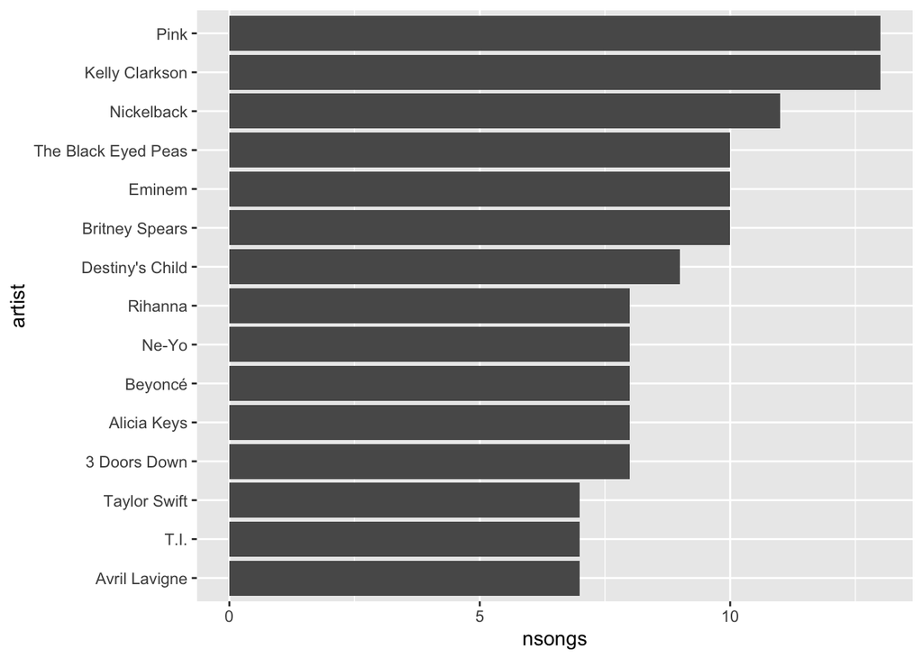

```r
ggplot(data = wiki_sort1, aes(x = artist,
                             y = nsongs)) +
  geom_col() +
  coord_flip()
```

Exercises 5.5.1:

```r
wiki_sort1 <- wiki_hot_100s %>%
  as_tibble() %>%
  filter(year <= 2009 & year >= 2000) %>%
  group_by(artist) %>%
  summarise(nsongs = n()) %>%
  slice_max(n = 15, order_by = nsongs) %>%
  mutate(artist = fct_reorder(artist, nsongs))

wiki_sort1
```

| artist | nsongs |
| --- | --- |
| Kelly Clarkson | 13 |
| Pink | 13 |
| Nickelback | 11 |
| Britney Spears | 10 |
| Eminem | 10 |
| The Black Eyed Peas | 10 |
| Destiny's Child | 9 |
| 3 Doors Down | 8 |
| Alicia Keys | 8 |
| Beyoncé | 8 |

[output cut: 5 more lines]

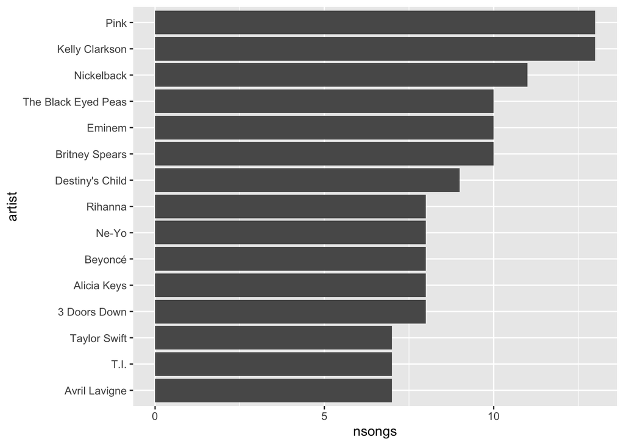

```r
ggplot(data = wiki_sort1, aes(x = artist,
                             y = nsongs)) +
  geom_col() +
  coord_flip()
```

```r
tail(wiki_hot_100s)
```

|  | no | title | artist | year |
| --- | --- | --- | --- | --- |
| 5696 | 95 | Adventure of a Lifetime | Coldplay | 2016 |
| 5697 | 96 | Humble and Kind | Tim McGraw | 2016 |
| 5698 | 97 | Wicked | Future | 2016 |
| 5699 | 98 | Tiimmy Turner | Desiigner | 2016 |
| 5700 | 99 | See You Again | Wiz Khalifa featuring Charlie Puth | 2016 |
| 5701 | 100 | Perfect | One Direction | 2016 |

I see that there are technically two artists in the song See You Again meaning that when we sort by artist, both artists will not receive credit for the song.

3. Fix the problem above

```r
wiki_hot_100s %>% as_tibble() %>%
  mutate(artist2 = str_remove(artist,
                              pattern = " featuring.*")) %>%
  tail() %>%
  print(width = Inf)
```

```
## # A tibble: 6 × 5
##   no    title                   artist                             year
##   <chr> <chr>                   <chr>                              <chr>
## 1 95    Adventure of a Lifetime Coldplay                           2016
## 2 96    Humble and Kind         Tim McGraw                         2016
## 3 97    Wicked                  Future                             2016
## 4 98    Tiimmy Turner           Desiigner                          2016
## 5 99    See You Again           Wiz Khalifa featuring Charlie Puth 2016
## 6 100   Perfect                 One Direction                      2016
##   artist2
##   <chr>
## 1 Coldplay
## 2 Tim McGraw
## 3 Future
## 4 Desiigner
## 5 Wiz Khalifa
## 6 One Direction
```

Exercise 2: Section 5.1 # 4, 5, 6, & 7

4 & 5)

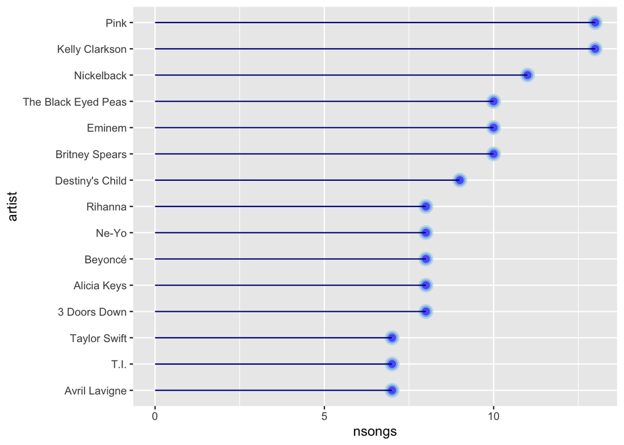

```r
# Libraries
library(ggplot2)


# Plot
ggplot(wiki_sort1, aes(x = artist, y = nsongs)) +
  geom_point(size=3, color="light blue", fill=alpha("blue", 0.3), alpha=0.7, shape=21, stroke=2) +
  geom_segment( aes(x=artist, xend=artist, y=0, yend=nsongs), color="dark blue")  + coord_flip()
```

Lollipop plots can be better than bar plots because the give a clear and emphasized endpoint.

More code:

```r
max(wiki_hot_100s$year)
```

```
## [1] "2016"
```

```
#> [1] "2016"
```

```r
library(rvest)
library(tidyverse)
## provide the URL and name it something (in this case, url).
## paste0 pastes together the base URL and the year into a single string:
## this will be useful in a moment
year <- 2017
url <- paste0("https://en.wikipedia.org/wiki/Billboard_Year-End_Hot_100_singles_of_", year)

## convert the html code into something R can read
h <- read_html(url)

## grabs the tables
tab <- h %>% html_nodes("table")
df <- tab[[1]] %>% html_table() %>%
  mutate(year = 2017)
df
```

| No. | Title | Artist(s) | year |
| --- | --- | --- | --- |
| 1 | "Shape of You" | Ed Sheeran | 2017 |
| 2 | "Despacito (Remix)" | Luis Fonsi and Daddy Yankee featuring Justin Bieber | 2017 |
| 3 | "That's What I Like" | Bruno Mars | 2017 |
| 4 | "Humble" | Kendrick Lamar | 2017 |
| 5 | "Something Just Like This" | The Chainsmokers and Coldplay | 2017 |
| 6 | "Bad and Boujee" | Migos featuring Lil Uzi Vert | 2017 |
| 7 | "Closer" | The Chainsmokers featuring Halsey | 2017 |
| 8 | "Body Like a Back Road" | Sam Hunt | 2017 |
| 9 | "Believer" | Imagine Dragons | 2017 |
| 10 | "Congratulations" | Post Malone featuring Quavo | 2017 |

[output cut: 90 more lines]

```
#> # A tibble: 100 x 4
#>      No. Title            `Artist(s)`                   year
#>    <int> <chr>            <chr>                        <dbl>
#>  1     1 "\"Shape of You… Ed Sheeran                    2017
#>  2     2 "\"Despacito (R… Luis Fonsi and Daddy Yankee…  2017
#>  3     3 "\"That's What … Bruno Mars                    2017
#>  4     4 "\"Humble\""     Kendrick Lamar                2017
#>  5     5 "\"Something Ju… The Chainsmokers and Coldpl…  2017
#>  6     6 "\"Bad and Bouj… Migos featuring Lil Uzi Vert  2017
#>  7     7 "\"Closer\""     The Chainsmokers featuring …  2017
#>  8     8 "\"Body Like a … Sam Hunt                      2017
#>  9     9 "\"Believer\""   Imagine Dragons               2017
#> 10    10 "\"Congratulati… Post Malone featuring Quavo   2017
#> # … with 90 more rows
#>
```

```r
get_wiki_100 <- function(year) {

  ## same code as before, replacing 2017 with year.
  url <- paste0("https://en.wikipedia.org/wiki/Billboard_Year-End_Hot_100_singles_of_", year)

  h <- read_html(url)

  tab <- h %>% html_nodes("table")
  df <- tab[[1]] %>% html_table() %>%
    mutate(year = year)

  ## tell our function to return the dataframe `df`
  return(df)
}

get_wiki_100(year = 2017)
```

| No. | Title | Artist(s) | year |
| --- | --- | --- | --- |
| 1 | "Shape of You" | Ed Sheeran | 2017 |
| 2 | "Despacito (Remix)" | Luis Fonsi and Daddy Yankee featuring Justin Bieber | 2017 |
| 3 | "That's What I Like" | Bruno Mars | 2017 |
| 4 | "Humble" | Kendrick Lamar | 2017 |
| 5 | "Something Just Like This" | The Chainsmokers and Coldplay | 2017 |
| 6 | "Bad and Boujee" | Migos featuring Lil Uzi Vert | 2017 |
| 7 | "Closer" | The Chainsmokers featuring Halsey | 2017 |
| 8 | "Body Like a Back Road" | Sam Hunt | 2017 |
| 9 | "Believer" | Imagine Dragons | 2017 |
| 10 | "Congratulations" | Post Malone featuring Quavo | 2017 |

[output cut: 90 more lines]

```
#> # A tibble: 100 x 4
#>      No. Title            `Artist(s)`                   year
#>    <int> <chr>            <chr>                        <dbl>
#>  1     1 "\"Shape of You… Ed Sheeran                    2017
#>  2     2 "\"Despacito (R… Luis Fonsi and Daddy Yankee…  2017
#>  3     3 "\"That's What … Bruno Mars                    2017
#>  4     4 "\"Humble\""     Kendrick Lamar                2017
#>  5     5 "\"Something Ju… The Chainsmokers and Coldpl…  2017
#>  6     6 "\"Bad and Bouj… Migos featuring Lil Uzi Vert  2017
#>  7     7 "\"Closer\""     The Chainsmokers featuring …  2017
#>  8     8 "\"Body Like a … Sam Hunt                      2017
#>  9     9 "\"Believer\""   Imagine Dragons               2017
#> 10    10 "\"Congratulati… Post Malone featuring Quavo   2017
#> # … with 90 more rows
#>
```

```r
library(purrr)
year_list <- list(2017, 2018, 2019, 2020, 2021)
year_list
```

```
## [[1]]
## [1] 2017
##
## [[2]]
## [1] 2018
##
## [[3]]
## [1] 2019
##
## [[4]]
## [1] 2020
##
## [[5]]
## [1] 2021
```

```
#> [[1]]
#> [1] 2017
#>
#> [[2]]
#> [1] 2018
#>
#> [[3]]
#> [1] 2019
#>
#> [[4]]
#> [1] 2020
#>
#> [[5]]
#> [1] 2021
```

```r
df_all <- map(year_list, get_wiki_100)
df_all ## a list of data frames, one for each year
```

```
## [[1]]
## # A tibble: 100 × 4
##      No. Title                          `Artist(s)`                         year
##    <int> <chr>                          <chr>                              <dbl>
##  1     1 "\"Shape of You\""             Ed Sheeran                          2017
##  2     2 "\"Despacito (Remix)\""        Luis Fonsi and Daddy Yankee featu…  2017
##  3     3 "\"That's What I Like\""       Bruno Mars                          2017
##  4     4 "\"Humble\""                   Kendrick Lamar                      2017
##  5     5 "\"Something Just Like This\"" The Chainsmokers and Coldplay       2017
##  6     6 "\"Bad and Boujee\""           Migos featuring Lil Uzi Vert        2017
##  7     7 "\"Closer\""                   The Chainsmokers featuring Halsey   2017
##  8     8 "\"Body Like a Back Road\""    Sam Hunt                            2017
##  9     9 "\"Believer\""                 Imagine Dragons                     2017
## 10    10 "\"Congratulations\""          Post Malone featuring Quavo         2017
## # … with 90 more rows
##
## [[2]]
## # A tibble: 100 × 4
##      No. Title                `Artist(s)`                                year
##    <int> <chr>                <chr>                                     <dbl>
##  1     1 "\"God's Plan\""     Drake                                      2018
##  2     2 "\"Perfect\""        Ed Sheeran                                 2018
##  3     3 "\"Meant to Be\""    Bebe Rexha featuring Florida Georgia Line  2018
##  4     4 "\"Havana\""         Camila Cabello featuring Young Thug        2018
##  5     5 "\"Rockstar\""       Post Malone featuring 21 Savage            2018
##  6     6 "\"Psycho\""         Post Malone featuring Ty Dolla Sign        2018
##  7     7 "\"I Like It\""      Cardi B, Bad Bunny and J Balvin            2018
##  8     8 "\"The Middle\""     Zedd, Maren Morris and Grey                2018
##  9     9 "\"In My Feelings\"" Drake                                      2018
## 10    10 "\"Girls Like You\"" Maroon 5 featuring Cardi B                 2018
## # … with 90 more rows
##
## [[3]]
## # A tibble: 100 × 4
##      No. Title               `Artist(s)`                          year
##    <int> <chr>               <chr>                               <dbl>
##  1     1 "\"Old Town Road\"" Lil Nas X featuring Billy Ray Cyrus  2019
##  2     2 "\"Sunflower\""     Post Malone and Swae Lee             2019
##  3     3 "\"Without Me\""    Halsey                               2019
##  4     4 "\"Bad Guy\""       Billie Eilish                        2019
```

[output cut: 24 more lines]

```
## [[5]]
## # A tibble: 100 × 4
##      No. Title                                `Artist(s)`                   year
##    <int> <chr>                                <chr>                        <dbl>
##  1     1 "\"Levitating\""                     Dua Lipa                      2021
##  2     2 "\"Save Your Tears\""                The Weeknd and Ariana Grande  2021
##  3     3 "\"Blinding Lights\""                The Weeknd                    2021
##  4     4 "\"Mood\""                           24kGoldn featuring Iann Dior  2021
##  5     5 "\"Good 4 U\""                       Olivia Rodrigo                2021
##  6     6 "\"Kiss Me More\""                   Doja Cat featuring SZA        2021
##  7     7 "\"Leave the Door Open\""            Silk Sonic (Bruno Mars and …  2021
##  8     8 "\"Drivers License\""                Olivia Rodrigo                2021
##  9     9 "\"Montero (Call Me by Your Name)\"" Lil Nas X                     2021
## 10    10 "\"Peaches\""                        Justin Bieber featuring Dan…  2021
## # … with 90 more rows
```

```
#> [[1]]
#> # A tibble: 100 x 4
#>      No. Title            `Artist(s)`                   year
#>    <int> <chr>            <chr>                        <dbl>
#>  1     1 "\"Shape of You… Ed Sheeran                    2017
#>  2     2 "\"Despacito (R… Luis Fonsi and Daddy Yankee…  2017
#>  3     3 "\"That's What … Bruno Mars                    2017
#>  4     4 "\"Humble\""     Kendrick Lamar                2017
#>  5     5 "\"Something Ju… The Chainsmokers and Coldpl…  2017
#>  6     6 "\"Bad and Bouj… Migos featuring Lil Uzi Vert  2017
#>  7     7 "\"Closer\""     The Chainsmokers featuring …  2017
#>  8     8 "\"Body Like a … Sam Hunt                      2017
#>  9     9 "\"Believer\""   Imagine Dragons               2017
#> 10    10 "\"Congratulati… Post Malone featuring Quavo   2017
#> # … with 90 more rows
#>
#> [[2]]
#> # A tibble: 100 x 4
#>      No. Title           `Artist(s)`                    year
#>    <int> <chr>           <chr>                         <dbl>
#>  1     1 "\"God's Plan\… Drake                          2018
#>  2     2 "\"Perfect\""   Ed Sheeran                     2018
#>  3     3 "\"Meant to Be… Bebe Rexha featuring Florida…  2018
#>  4     4 "\"Havana\""    Camila Cabello featuring You…  2018
#>  5     5 "\"Rockstar\""  Post Malone featuring 21 Sav…  2018
#>  6     6 "\"Psycho\""    Post Malone featuring Ty Dol…  2018
#>  7     7 "\"I Like It\"" Cardi B, Bad Bunny and J Bal…  2018
#>  8     8 "\"The Middle\… Zedd, Maren Morris and Grey    2018
#>  9     9 "\"In My Feeli… Drake                          2018
#> 10    10 "\"Girls Like … Maroon 5 featuring Cardi B     2018
#> # … with 90 more rows
#>
#> [[3]]
#> # A tibble: 100 x 4
#>      No. Title            `Artist(s)`                   year
#>    <int> <chr>            <chr>                        <dbl>
#>  1     1 "\"Old Town Roa… Lil Nas X featuring Billy R…  2019
#>  2     2 "\"Sunflower\""  Post Malone and Swae Lee      2019
#>  3     3 "\"Without Me\"" Halsey                        2019
#>  4     4 "\"Bad Guy\""    Billie Eilish                 2019
```

[output cut: 24 more lines]

```
#> [[5]]
#> # A tibble: 100 x 4
#>      No. Title              `Artist(s)`                 year
#>    <int> <chr>              <chr>                      <dbl>
#>  1     1 "\"Levitating\""   Dua Lipa                    2021
#>  2     2 "\"Save Your Tear… The Weeknd and Ariana Gra…  2021
#>  3     3 "\"Blinding Light… The Weeknd                  2021
#>  4     4 "\"Mood\""         24kGoldn featuring Iann D…  2021
#>  5     5 "\"Good 4 U\""     Olivia Rodrigo              2021
#>  6     6 "\"Kiss Me More\"" Doja Cat featuring SZA      2021
#>  7     7 "\"Leave the Door… Silk Sonic (Bruno Mars an…  2021
#>  8     8 "\"Drivers Licens… Olivia Rodrigo              2021
#>  9     9 "\"Montero (Call … Lil Nas X                   2021
#> 10    10 "\"Peaches\""      Justin Bieber featuring D…  2021
#> # … with 90 more rows
```

```r
df_2017_present <- bind_rows(df_all)

 df_2017_present %>%
  mutate(Title = str_remove_all(Title, pattern = "\"")) %>% ## get rid of \ in title
  rename(no = No.,
         title = Title,
         artist = `Artist(s)`) ## make column names match with billboard package
```

| no | title | artist | year |
| --- | --- | --- | --- |
| 1 | Shape of You | Ed Sheeran | 2017 |
| 2 | Despacito (Remix) | Luis Fonsi and Daddy Yankee featuring Justin Bieber | 2017 |
| 3 | That's What I Like | Bruno Mars | 2017 |
| 4 | Humble | Kendrick Lamar | 2017 |
| 5 | Something Just Like This | The Chainsmokers and Coldplay | 2017 |
| 6 | Bad and Boujee | Migos featuring Lil Uzi Vert | 2017 |
| 7 | Closer | The Chainsmokers featuring Halsey | 2017 |
| 8 | Body Like a Back Road | Sam Hunt | 2017 |
| 9 | Believer | Imagine Dragons | 2017 |
| 10 | Congratulations | Post Malone featuring Quavo | 2017 |

[output cut: 490 more lines]

```r
wiki_tibble <- as_tibble(wiki_hot_100s) %>% ## convert billboard data to tibble
  mutate(year = as.numeric(year),
         no = as.integer(no)) ## change variable types to match with scraped data
hot100_df <- bind_rows(wiki_tibble, df_2017_present)

hot100_df
```

| no | title | artist | year | No. | Title | Artist(s) |
| --- | --- | --- | --- | --- | --- | --- |
| 1 | Theme from A Summer Place | Percy Faith | 1960 | NA | NA | NA |
| 2 | He'll Have to Go | Jim Reeves | 1960 | NA | NA | NA |
| 3 | Cathy's Clown | The Everly Brothers | 1960 | NA | NA | NA |
| 4 | Running Bear | Johnny Preston | 1960 | NA | NA | NA |
| 5 | Teen Angel | Mark Dinning | 1960 | NA | NA | NA |
| 6 | I'm Sorry | Brenda Lee | 1960 | NA | NA | NA |
| 7 | It's Now or Never | Elvis Presley | 1960 | NA | NA | NA |
| 8 | Handy Man | Jimmy Jones | 1960 | NA | NA | NA |
| 9 | Stuck on You | Elvis Presley | 1960 | NA | NA | NA |
| 10 | The Twist | Chubby Checker | 1960 | NA | NA | NA |

[output cut: 6191 more lines]

```r
 sort_hot100 <- hot100_df %>%
  as_tibble() %>%
  filter(year <= 2020 & year >= 2010) %>%
  group_by(artist) %>%
  summarise(nsongs = n()) %>% arrange(desc(nsongs)) %>%
  slice(2:11) %>%
  mutate(artist = fct_reorder(artist, nsongs))

sort_hot100
```

| artist | nsongs |
| --- | --- |
| Taylor Swift | 13 |
| Rihanna | 12 |
| Adele | 10 |
| Katy Perry | 10 |
| Drake | 9 |
| Maroon 5 | 9 |
| Bruno Mars | 8 |
| Jason Derulo | 7 |
| Kesha | 7 |
| Lady Gaga | 7 |

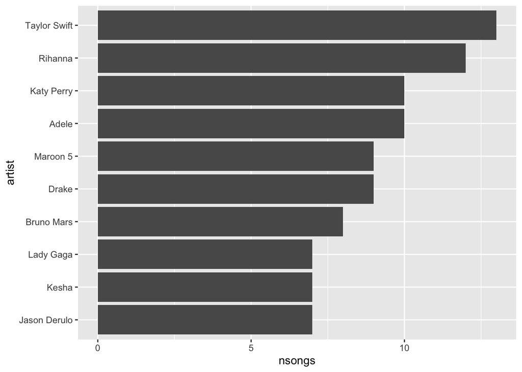

```r
ggplot(data = sort_hot100, aes(x = artist,
                             y = nsongs)) +
  geom_col() +
  coord_flip()
```

7) Sometimes we want data from a public website that isn’t provided in a file format. To obtain this data, you’ll need to use web scraping, and the easiest way to do this in R is with the rvest package. If we want to iterate over a span of years, using the purrr package is the least tedious and more effective way of doing so, by using functional programming concepts to iterate.

```r
library(rvest)
library(tidyverse)

# url <- https://en.wikipedia.org/wiki/COVID-19_pandemic_by_country_and_territory
```

I was kinda confused on how do do this. Could we briefly go over it in class some time if we have time?

Back to 5.2: More tidyverse Review: Happy Planet Index

5.2.1

```r
library(tidyverse)
hpi_df <- read_csv("/Users/gracewysocki/Desktop/Data Vis/data/hpi-tidy.csv")
hpi_df
```

| HPIRank | Country | LifeExpectancy | Wellbeing | HappyLifeYears | Footprint | HappyPlanetIndex | Population | GDPcapita | GovernanceRank | Region |
| --- | --- | --- | --- | --- | --- | --- | --- | --- | --- | --- |
| 109 | Afghanistan | 48.7 | 4.758381 | 28.96389 | 0.5403336 | 36.75366 | 34385000 | 1207.2802 | 150 | Middle East and North Africa |
| 18 | Albania | 76.9 | 5.268937 | 48.77113 | 1.8119056 | 54.05118 | 3205000 | 8592.1688 | 65 | Transition States |
| 26 | Algeria | 73.1 | 5.236961 | 46.18039 | 1.6481423 | 52.18130 | 35468000 | 8432.8747 | 118 | Middle East and North Africa |
| 127 | Angola | 51.1 | 4.206092 | 28.20927 | 0.8906109 | 33.20143 | 19082000 | 6186.4900 | 129 | Sub Saharan Africa |
| 17 | Argentina | 75.9 | 6.441067 | 55.01528 | 2.7090712 | 54.05504 | 40412000 | 16011.6728 | 73 | Latin America |
| 53 | Armenia | 74.2 | 4.367811 | 41.88916 | 1.7334406 | 46.00319 | 3092000 | 5463.2032 | 77 | Transition States |
| 76 | Australia | 81.9 | 7.405616 | 65.47198 | 6.6849916 | 41.97981 | 22299000 | 38159.6337 | 10 | Western World |
| 48 | Austria | 80.9 | 7.346036 | 64.29990 | 5.2913456 | 47.08514 | 8390000 | 40006.1869 | 11 | Western World |
| 80 | Azerbaijan | 70.7 | 4.218611 | 39.09769 | 1.9688118 | 40.88457 | 9054000 | 9935.9244 | 114 | Transition States |
| 146 | Bahrain | 75.1 | 4.549466 | 43.45201 | 6.6451305 | 26.61785 | 1262000 | 25799.4916 | 52 | Middle East and North Africa |

[output cut: 141 more lines]

```
#> # A tibble: 151 x 11
#>    HPIRank Country   LifeExpectancy Wellbeing HappyLifeYears
#>      <dbl> <chr>              <dbl>     <dbl>          <dbl>
#>  1     109 Afghanis…           48.7      4.76           29.0
#>  2      18 Albania             76.9      5.27           48.8
#>  3      26 Algeria             73.1      5.24           46.2
#>  4     127 Angola              51.1      4.21           28.2
#>  5      17 Argentina           75.9      6.44           55.0
#>  6      53 Armenia             74.2      4.37           41.9
#>  7      76 Australia           81.9      7.41           65.5
#>  8      48 Austria             80.9      7.35           64.3
#>  9      80 Azerbaij…           70.7      4.22           39.1
#> 10     146 Bahrain             75.1      4.55           43.5
#> # … with 141 more rows, and 6 more variables:
#> #   Footprint <dbl>, HappyPlanetIndex <dbl>,
#> #   Population <dbl>, GDPcapita <dbl>,
#> #   GovernanceRank <chr>, Region <chr>
#>
```

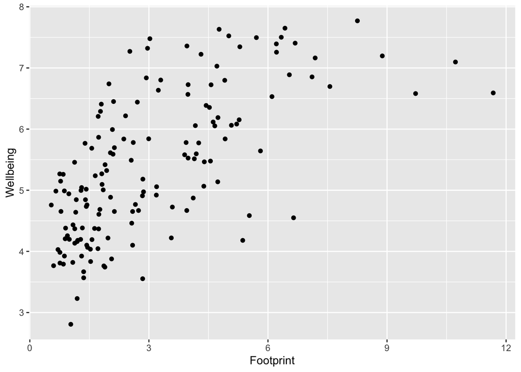

```r
ggplot(data = hpi_df, aes(x = Footprint, y = Wellbeing)) +
  geom_point()
```

```r
hpi_us <- hpi_df %>% filter(Country == "United States of America" |
                             Country == "Kenya" |
                            Country == "Brazil")
hpi_us
```

| HPIRank | Country | LifeExpectancy | Wellbeing | HappyLifeYears | Footprint | HappyPlanetIndex | Population | GDPcapita | GovernanceRank | Region |
| --- | --- | --- | --- | --- | --- | --- | --- | --- | --- | --- |
| 21 | Brazil | 73.5 | 6.837331 | 55.52751 | 2.9347647 | 52.93200 | 194946000 | 11210.391 | 53 | Latin America |
| 98 | Kenya | 57.1 | 4.255859 | 31.74122 | 0.9468026 | 37.99964 | 40513000 | 1651.232 | 107 | Sub Saharan Africa |
| 105 | United States of America | 78.5 | 7.163616 | 61.28521 | 7.1891330 | 37.34011 | 309349000 | 47153.009 | 21 | Western World |

[output not shown]

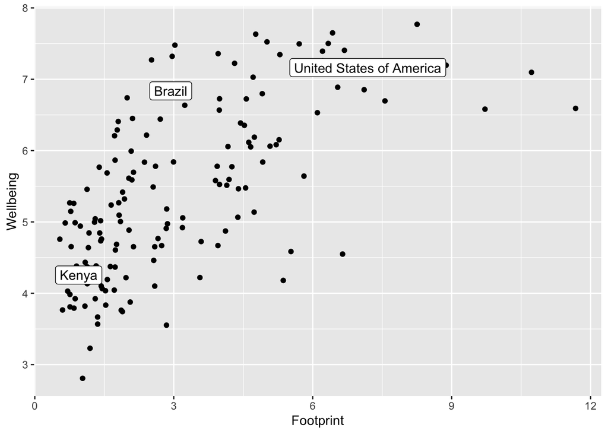

```r
ggplot(data = hpi_df, aes(x = Footprint, y = Wellbeing)) +
  geom_point() +
  geom_label(data = hpi_us, aes(label = Country)) ## specify
```

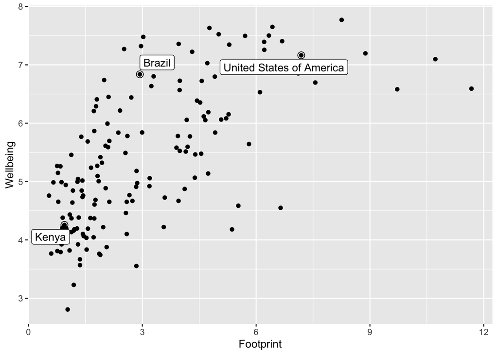

```r
library(ggrepel)
ggplot(data = hpi_df, aes(x = Footprint, y = Wellbeing)) +
  geom_point() +
  geom_label_repel(data = hpi_us, aes(label = Country)) +
  geom_point(data = hpi_us, size = 3, shape = 1) ## create a second point that is an open circle (shape = 1) with a larger size (size = 3) to surround the United States point on the scatterplot
```

5.2.2

```r
#install.packages("plotly")
library(plotly)
```